# R Assignment - NK

Nathan Kreuter

2026-03-15

#Part 1 ##Data Inspection

Clear environment, import data, and load libraries.

Look at: 1) File structure

```r
str(snp)
str(fang)
```

2. First lines

```r
head(snp)
head(fang)
```

3. Dimensions

```r
dim(snp)
dim(fang)
```

4. Rows and columns

```r
nrow(snp); ncol(snp)
nrow(fang); ncol(fang)
```

5. Variable summary

```r
summary(snp)
summary(fang)
```

#Data Processing

Filter the fang dataset into one containing maize genotypes and teosinte genoytpes. Then transpose the filtered datasets separately.

```r
fang_maize <- fang[ fang[,3] %in% c("ZMMIL", "ZMMLR", "ZMMMR"), ]
fang_teosinte <- fang[ fang[,3] %in% c("ZMPBA", "ZMPIL", "ZMPJA"), ]

genotypes_maize <- t(fang_maize[,-(1:3)])
genotypes_teosinte <- t(fang_teosinte[,-(1:3)])
```

Make a column labeled SNP_ID containing the row names which can be used to join with the snp file.

```r
genotypes_maize_df <- data.frame(SNP_ID = rownames(genotypes_maize), genotypes_maize, check.names = FALSE)
genotypes_teosinte_df <- data.frame(SNP_ID = rownames(genotypes_teosinte), genotypes_teosinte, check.names = FALSE)

joined_maize <- inner_join(snp, genotypes_maize_df, by = "SNP_ID")
joined_teosinte <- inner_join(snp, genotypes_teosinte_df, by = "SNP_ID")
```

Remove columns 2, and 5-15 to leave behind only SNP_ID, Chromosome, Position, and genotype data. Also, make the “Position” column numeric for sorting by increasing/decreasing position

```r
fang_maize_clean    <- joined_maize[, -c(2, 5:15)]
fang_teosinte_clean <- joined_teosinte[, -c(2, 5:15)]

fang_maize_clean$Position <- as.numeric(fang_maize_clean$Position)
fang_teosinte_clean$Position <- as.numeric(fang_teosinte_clean$Position)
```

Sort by Chromosome and order based on Position, and replace missing data respectively. For maize in increasing order and replacing missing data with “?”

```r
maize_inc_chr1 <- fang_maize_clean[fang_maize_clean$Chromosome == 1, ][order(fang_maize_clean[fang_maize_clean$Chromosome == 1, ]$Position), ]
maize_inc_chr1[,4:ncol(maize_inc_chr1)][maize_inc_chr1[,4:ncol(maize_inc_chr1)] == "?/?"] <- "?"
maize_inc_chr2 <- fang_maize_clean[fang_maize_clean$Chromosome == 2, ][order(fang_maize_clean[fang_maize_clean$Chromosome == 2, ]$Position), ]
maize_inc_chr2[,4:ncol(maize_inc_chr2)][maize_inc_chr2[,4:ncol(maize_inc_chr2)] == "?/?"] <- "?"
maize_inc_chr3 <- fang_maize_clean[fang_maize_clean$Chromosome == 3, ][order(fang_maize_clean[fang_maize_clean$Chromosome == 3, ]$Position), ]
maize_inc_chr3[,4:ncol(maize_inc_chr1)][maize_inc_chr3[,4:ncol(maize_inc_chr3)] == "?/?"] <- "?"
maize_inc_chr4 <- fang_maize_clean[fang_maize_clean$Chromosome == 4, ][order(fang_maize_clean[fang_maize_clean$Chromosome == 4, ]$Position), ]
maize_inc_chr4[,4:ncol(maize_inc_chr4)][maize_inc_chr4[,4:ncol(maize_inc_chr4)] == "?/?"] <- "?"
maize_inc_chr5 <- fang_maize_clean[fang_maize_clean$Chromosome == 5, ][order(fang_maize_clean[fang_maize_clean$Chromosome == 5, ]$Position), ]
maize_inc_chr5[,4:ncol(maize_inc_chr5)][maize_inc_chr5[,4:ncol(maize_inc_chr5)] == "?/?"] <- "?"
maize_inc_chr6 <- fang_maize_clean[fang_maize_clean$Chromosome == 6, ][order(fang_maize_clean[fang_maize_clean$Chromosome == 6, ]$Position), ]
maize_inc_chr6[,4:ncol(maize_inc_chr6)][maize_inc_chr6[,4:ncol(maize_inc_chr6)] == "?/?"] <- "?"
maize_inc_chr7 <- fang_maize_clean[fang_maize_clean$Chromosome == 7, ][order(fang_maize_clean[fang_maize_clean$Chromosome == 7, ]$Position), ]
maize_inc_chr7[,4:ncol(maize_inc_chr7)][maize_inc_chr7[,4:ncol(maize_inc_chr7)] == "?/?"] <- "?"
maize_inc_chr8 <- fang_maize_clean[fang_maize_clean$Chromosome == 8, ][order(fang_maize_clean[fang_maize_clean$Chromosome == 8, ]$Position), ]
maize_inc_chr8[,4:ncol(maize_inc_chr8)][maize_inc_chr8[,4:ncol(maize_inc_chr8)] == "?/?"] <- "?"
maize_inc_chr9 <- fang_maize_clean[fang_maize_clean$Chromosome == 9, ][order(fang_maize_clean[fang_maize_clean$Chromosome == 9, ]$Position), ]
maize_inc_chr9[,4:ncol(maize_inc_chr9)][maize_inc_chr9[,4:ncol(maize_inc_chr9)] == "?/?"] <- "?"
maize_inc_chr10 <- fang_maize_clean[fang_maize_clean$Chromosome == 10, ][order(fang_maize_clean[fang_maize_clean$Chromosome == 10, ]$Position), ]
maize_inc_chr10[,4:ncol(maize_inc_chr10)][maize_inc_chr10[,4:ncol(maize_inc_chr10)] == "?/?"] <- "?"
```

For maize in decreasing order and replacing missing data with “-”

```r
maize_dec_chr1 <- fang_maize_clean[fang_maize_clean$Chromosome == 1, ][order(fang_maize_clean[fang_maize_clean$Chromosome == 1, ]$Position, decreasing = TRUE), ]
maize_dec_chr1[,4:ncol(maize_dec_chr1)][maize_dec_chr1[,4:ncol(maize_dec_chr1)] == "?/?"] <- "-"
maize_dec_chr2 <- fang_maize_clean[fang_maize_clean$Chromosome == 2, ][order(fang_maize_clean[fang_maize_clean$Chromosome == 2, ]$Position, decreasing = TRUE), ]
maize_dec_chr2[,4:ncol(maize_dec_chr2)][maize_dec_chr2[,4:ncol(maize_dec_chr2)] == "?/?"] <- "-"
maize_dec_chr3 <- fang_maize_clean[fang_maize_clean$Chromosome == 3, ][order(fang_maize_clean[fang_maize_clean$Chromosome == 3, ]$Position, decreasing = TRUE), ]
maize_dec_chr3[,4:ncol(maize_dec_chr3)][maize_dec_chr3[,4:ncol(maize_dec_chr3)] == "?/?"] <- "-"
maize_dec_chr4 <- fang_maize_clean[fang_maize_clean$Chromosome == 4, ][order(fang_maize_clean[fang_maize_clean$Chromosome == 4, ]$Position, decreasing = TRUE), ]
maize_dec_chr4[,4:ncol(maize_dec_chr4)][maize_dec_chr4[,4:ncol(maize_dec_chr4)] == "?/?"] <- "-"
maize_dec_chr5 <- fang_maize_clean[fang_maize_clean$Chromosome == 5, ][order(fang_maize_clean[fang_maize_clean$Chromosome == 5, ]$Position, decreasing = TRUE), ]
maize_dec_chr5[,4:ncol(maize_dec_chr5)][maize_dec_chr5[,4:ncol(maize_dec_chr5)] == "?/?"] <- "-"
maize_dec_chr6 <- fang_maize_clean[fang_maize_clean$Chromosome == 6, ][order(fang_maize_clean[fang_maize_clean$Chromosome == 6, ]$Position, decreasing = TRUE), ]
maize_dec_chr6[,4:ncol(maize_dec_chr6)][maize_dec_chr6[,4:ncol(maize_dec_chr6)] == "?/?"] <- "-"
maize_dec_chr7 <- fang_maize_clean[fang_maize_clean$Chromosome == 7, ][order(fang_maize_clean[fang_maize_clean$Chromosome == 7, ]$Position, decreasing = TRUE), ]
maize_dec_chr7[,4:ncol(maize_dec_chr7)][maize_dec_chr7[,4:ncol(maize_dec_chr7)] == "?/?"] <- "-"
maize_dec_chr8 <- fang_maize_clean[fang_maize_clean$Chromosome == 8, ][order(fang_maize_clean[fang_maize_clean$Chromosome == 8, ]$Position, decreasing = TRUE), ]
maize_dec_chr8[,4:ncol(maize_dec_chr8)][maize_dec_chr8[,4:ncol(maize_dec_chr8)] == "?/?"] <- "-"
maize_dec_chr9 <- fang_maize_clean[fang_maize_clean$Chromosome == 9, ][order(fang_maize_clean[fang_maize_clean$Chromosome == 9, ]$Position, decreasing = TRUE), ]
maize_dec_chr9[,4:ncol(maize_dec_chr9)][maize_dec_chr9[,4:ncol(maize_dec_chr9)] == "?/?"] <- "-"
maize_dec_chr10 <- fang_maize_clean[fang_maize_clean$Chromosome == 10, ][order(fang_maize_clean[fang_maize_clean$Chromosome == 10, ]$Position, decreasing = TRUE), ]
maize_dec_chr10[,4:ncol(maize_dec_chr10)][maize_dec_chr10[,4:ncol(maize_dec_chr10)] == "?/?"] <- "-"
```

For teosinte in increasing order and replacing missing data with “?”

```r
teosinte_inc_chr1 <- fang_teosinte_clean[fang_teosinte_clean$Chromosome == 1, ][order(fang_teosinte_clean[fang_teosinte_clean$Chromosome == 1, ]$Position), ]
teosinte_inc_chr1[,4:ncol(teosinte_inc_chr1)][teosinte_inc_chr1[,4:ncol(teosinte_inc_chr1)] == "?/?"] <- "?"
teosinte_inc_chr2 <- fang_teosinte_clean[fang_teosinte_clean$Chromosome == 2, ][order(fang_teosinte_clean[fang_teosinte_clean$Chromosome == 2, ]$Position), ]
teosinte_inc_chr2[,4:ncol(teosinte_inc_chr2)][teosinte_inc_chr2[,4:ncol(teosinte_inc_chr2)] == "?/?"] <- "?"
teosinte_inc_chr3 <- fang_teosinte_clean[fang_teosinte_clean$Chromosome == 3, ][order(fang_teosinte_clean[fang_teosinte_clean$Chromosome == 3, ]$Position), ]
teosinte_inc_chr3[,4:ncol(teosinte_inc_chr3)][teosinte_inc_chr3[,4:ncol(teosinte_inc_chr3)] == "?/?"] <- "?"
teosinte_inc_chr4 <- fang_teosinte_clean[fang_teosinte_clean$Chromosome == 4, ][order(fang_teosinte_clean[fang_teosinte_clean$Chromosome == 4, ]$Position), ]
teosinte_inc_chr4[,4:ncol(teosinte_inc_chr4)][teosinte_inc_chr4[,4:ncol(teosinte_inc_chr4)] == "?/?"] <- "?"
teosinte_inc_chr5 <- fang_teosinte_clean[fang_teosinte_clean$Chromosome == 5, ][order(fang_teosinte_clean[fang_teosinte_clean$Chromosome == 5, ]$Position), ]
teosinte_inc_chr5[,4:ncol(teosinte_inc_chr5)][teosinte_inc_chr5[,4:ncol(teosinte_inc_chr5)] == "?/?"] <- "?"
teosinte_inc_chr6 <- fang_teosinte_clean[fang_teosinte_clean$Chromosome == 6, ][order(fang_teosinte_clean[fang_teosinte_clean$Chromosome == 6, ]$Position), ]
teosinte_inc_chr6[,4:ncol(teosinte_inc_chr6)][teosinte_inc_chr6[,4:ncol(teosinte_inc_chr6)] == "?/?"] <- "?"
teosinte_inc_chr7 <- fang_teosinte_clean[fang_teosinte_clean$Chromosome == 7, ][order(fang_teosinte_clean[fang_teosinte_clean$Chromosome == 7, ]$Position), ]
teosinte_inc_chr7[,4:ncol(teosinte_inc_chr7)][teosinte_inc_chr7[,4:ncol(teosinte_inc_chr7)] == "?/?"] <- "?"
teosinte_inc_chr8 <- fang_teosinte_clean[fang_teosinte_clean$Chromosome == 8, ][order(fang_teosinte_clean[fang_teosinte_clean$Chromosome == 8, ]$Position), ]
teosinte_inc_chr8[,4:ncol(teosinte_inc_chr8)][teosinte_inc_chr8[,4:ncol(teosinte_inc_chr8)] == "?/?"] <- "?"
teosinte_inc_chr9 <- fang_teosinte_clean[fang_teosinte_clean$Chromosome == 9, ][order(fang_teosinte_clean[fang_teosinte_clean$Chromosome == 9, ]$Position), ]
teosinte_inc_chr9[,4:ncol(teosinte_inc_chr9)][teosinte_inc_chr9[,4:ncol(teosinte_inc_chr9)] == "?/?"] <- "?"
teosinte_inc_chr10 <- fang_teosinte_clean[fang_teosinte_clean$Chromosome == 10, ][order(fang_teosinte_clean[fang_teosinte_clean$Chromosome == 10, ]$Position), ]
teosinte_inc_chr10[,4:ncol(teosinte_inc_chr10)][teosinte_inc_chr10[,4:ncol(teosinte_inc_chr10)] == "?/?"] <- "?"
```

For teosinte in decreasing order and replacing missing data with “-”

```r
teosinte_dec_chr1 <- fang_teosinte_clean[fang_teosinte_clean$Chromosome == 1, ][order(fang_teosinte_clean[fang_teosinte_clean$Chromosome == 1, ]$Position, decreasing = TRUE), ]
teosinte_dec_chr1[,4:ncol(teosinte_dec_chr1)][teosinte_dec_chr1[,4:ncol(teosinte_dec_chr1)] == "?/?"] <- "-"
teosinte_dec_chr2 <- fang_teosinte_clean[fang_teosinte_clean$Chromosome == 2, ][order(fang_teosinte_clean[fang_teosinte_clean$Chromosome == 2, ]$Position, decreasing = TRUE), ]
teosinte_dec_chr2[,4:ncol(teosinte_dec_chr2)][teosinte_dec_chr2[,4:ncol(teosinte_dec_chr2)] == "?/?"] <- "-"
teosinte_dec_chr3 <- fang_teosinte_clean[fang_teosinte_clean$Chromosome == 3, ][order(fang_teosinte_clean[fang_teosinte_clean$Chromosome == 3, ]$Position, decreasing = TRUE), ]
teosinte_dec_chr3[,4:ncol(teosinte_dec_chr3)][teosinte_dec_chr3[,4:ncol(teosinte_dec_chr3)] == "?/?"] <- "-"
teosinte_dec_chr4 <- fang_teosinte_clean[fang_teosinte_clean$Chromosome == 4, ][order(fang_teosinte_clean[fang_teosinte_clean$Chromosome == 4, ]$Position, decreasing = TRUE), ]
teosinte_dec_chr4[,4:ncol(teosinte_dec_chr4)][teosinte_dec_chr4[,4:ncol(teosinte_dec_chr4)] == "?/?"] <- "-"
teosinte_dec_chr5 <- fang_teosinte_clean[fang_teosinte_clean$Chromosome == 5, ][order(fang_teosinte_clean[fang_teosinte_clean$Chromosome == 5, ]$Position, decreasing = TRUE), ]
teosinte_dec_chr5[,4:ncol(teosinte_dec_chr5)][teosinte_dec_chr5[,4:ncol(teosinte_dec_chr5)] == "?/?"] <- "-"
teosinte_dec_chr6 <- fang_teosinte_clean[fang_teosinte_clean$Chromosome == 6, ][order(fang_teosinte_clean[fang_teosinte_clean$Chromosome == 6, ]$Position, decreasing = TRUE), ]
teosinte_dec_chr6[,4:ncol(teosinte_dec_chr6)][teosinte_dec_chr6[,4:ncol(teosinte_dec_chr6)] == "?/?"] <- "-"
teosinte_dec_chr7 <- fang_teosinte_clean[fang_teosinte_clean$Chromosome == 7, ][order(fang_teosinte_clean[fang_teosinte_clean$Chromosome == 7, ]$Position, decreasing = TRUE), ]
teosinte_dec_chr7[,4:ncol(teosinte_dec_chr7)][teosinte_dec_chr7[,4:ncol(teosinte_dec_chr7)] == "?/?"] <- "-"
teosinte_dec_chr8 <- fang_teosinte_clean[fang_teosinte_clean$Chromosome == 8, ][order(fang_teosinte_clean[fang_teosinte_clean$Chromosome == 8, ]$Position, decreasing = TRUE), ]
teosinte_dec_chr8[,4:ncol(teosinte_dec_chr8)][teosinte_dec_chr8[,4:ncol(teosinte_dec_chr8)] == "?/?"] <- "-"
teosinte_dec_chr9 <- fang_teosinte_clean[fang_teosinte_clean$Chromosome == 9, ][order(fang_teosinte_clean[fang_teosinte_clean$Chromosome == 9, ]$Position, decreasing = TRUE), ]
teosinte_dec_chr9[,4:ncol(teosinte_dec_chr9)][teosinte_dec_chr9[,4:ncol(teosinte_dec_chr9)] == "?/?"] <- "-"
teosinte_dec_chr10 <- fang_teosinte_clean[fang_teosinte_clean$Chromosome == 10, ][order(fang_teosinte_clean[fang_teosinte_clean$Chromosome == 10, ]$Position, decreasing = TRUE), ]
teosinte_dec_chr10[,4:ncol(teosinte_dec_chr10)][teosinte_dec_chr10[,4:ncol(teosinte_dec_chr10)] == "?/?"] <- "-"
```

#Part 2 ##Visualization

##SNPs per chromosome

```r
snp_filtered <- fang_maize_clean %>%
  filter(!(Chromosome %in% c("unknown", "multiple")))

snp_filtered <- snp_filtered %>%
  mutate(Chromosome = factor(Chromosome, levels = as.character(1:10)))
```

Plot snp_filtered. This will show how each SNP_ID is positioned across the chromosomes.

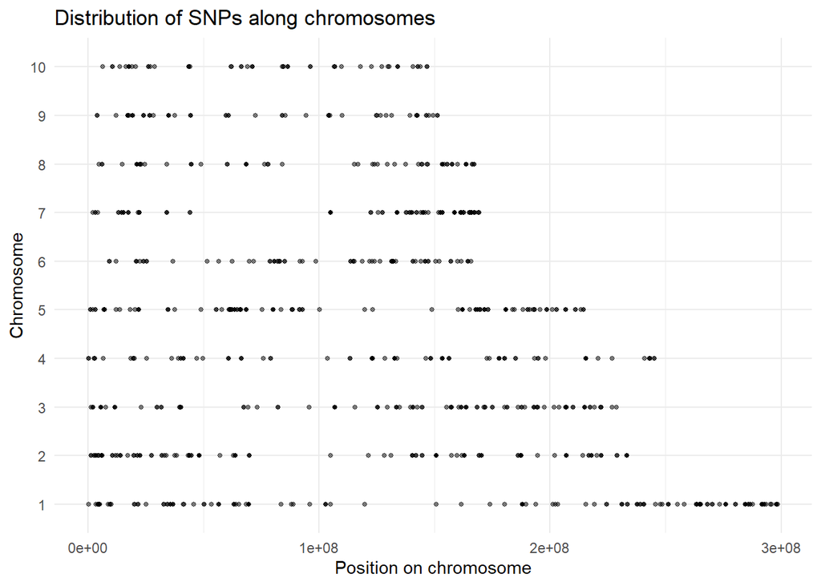

```r
ggplot(snp_filtered, aes(x = Position, y = factor(Chromosome))) +
  geom_point(alpha = 0.5, size = 1) +
  labs(x = "Position on chromosome",
       y = "Chromosome",
       title = "Distribution of SNPs along chromosomes") +
  theme_minimal()
```

##Missing data and amount of heterozygosity To see if there are more SNP positions in maize or teosinte, start by converting the dataset from wide to long.

```r
maize_long <- fang_maize_clean %>%
  pivot_longer(
    cols = 4:ncol(fang_maize_clean),
    names_to = "Sample",
    values_to = "Genotype")

teosinte_long <- fang_teosinte_clean %>%
  pivot_longer(
    cols = 4:ncol(fang_teosinte_clean),
    names_to = "Sample",
    values_to = "Genotype")
```

This code creates a new “SiteType” column and uses case_when to identify if nucleotides follow a homozygous/heterozygous/missng pattern and labels accordingly for each SNP_ID. A “Group” column is also added to each long and labeled maize/teosinte respectively. These files are then combined.

```r
maize_long <- maize_long %>%
  mutate(SiteType = case_when(
    Genotype == "?/?" ~ "Missing",
    sub("/.*","",Genotype) == sub(".*/","",Genotype) ~ "Homozygous",
    TRUE ~ "Heterozygous"))
teosinte_long <- teosinte_long %>%
  mutate(SiteType = case_when(
    Genotype == "?/?" ~ "Missing",
    sub("/.*","",Genotype) == sub(".*/","",Genotype) ~ "Homozygous",
    TRUE ~ "Heterozygous"))

maize_long$Group <- "Maize"
teosinte_long$Group <- "Teosinte"
combined_long <- rbind(maize_long, teosinte_long)
```

Plot the proportion of homozygous, heterozygous, and missing sites in each sample for each group, then across groups.

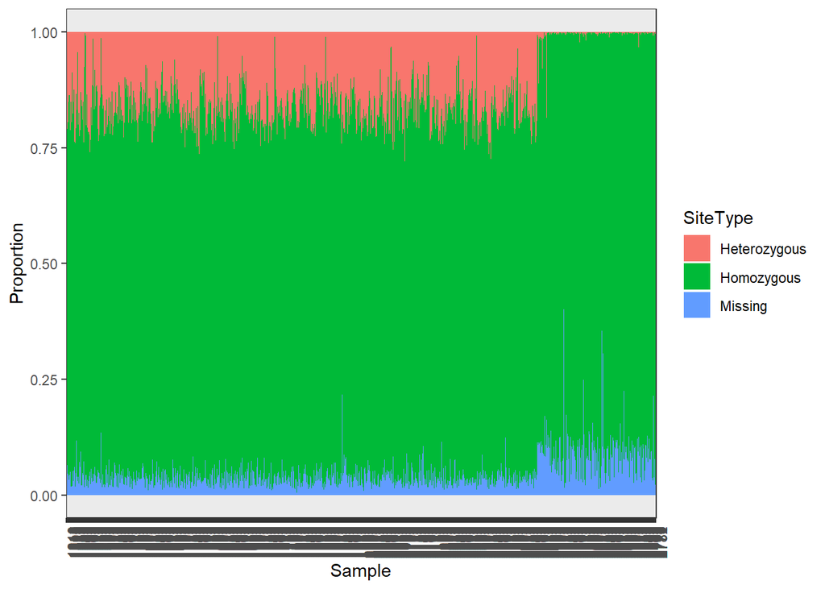

```r
ggplot(maize_long, aes(x = Sample, fill = SiteType)) +
  geom_bar(position = "fill") +
  ylab("Proportion") +
  theme_bw() +
  theme(axis.text.x = element_text(angle = 90, hjust = 1))
```

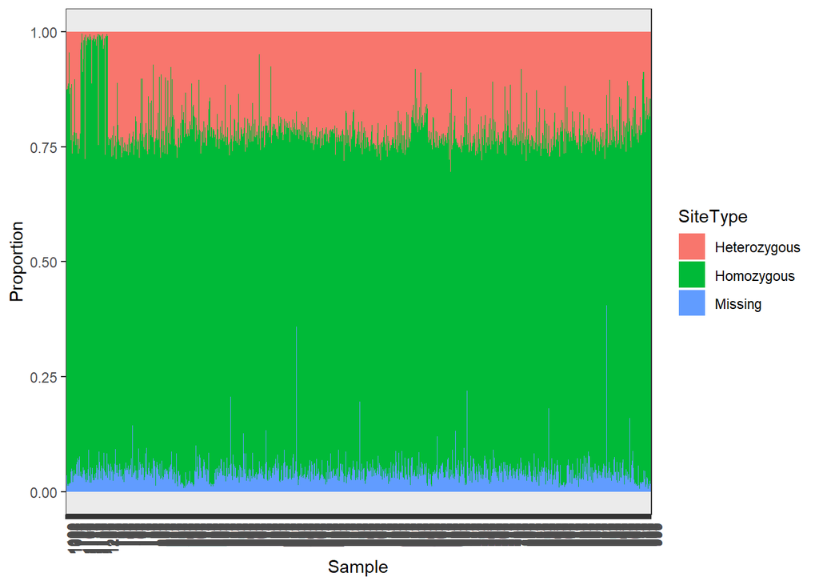

```r
ggplot(teosinte_long, aes(x = Sample, fill = SiteType)) +
  geom_bar(position = "fill") +
  ylab("Proportion") +
  theme_bw() +
  theme(axis.text.x = element_text(angle = 90, hjust = 1))
```

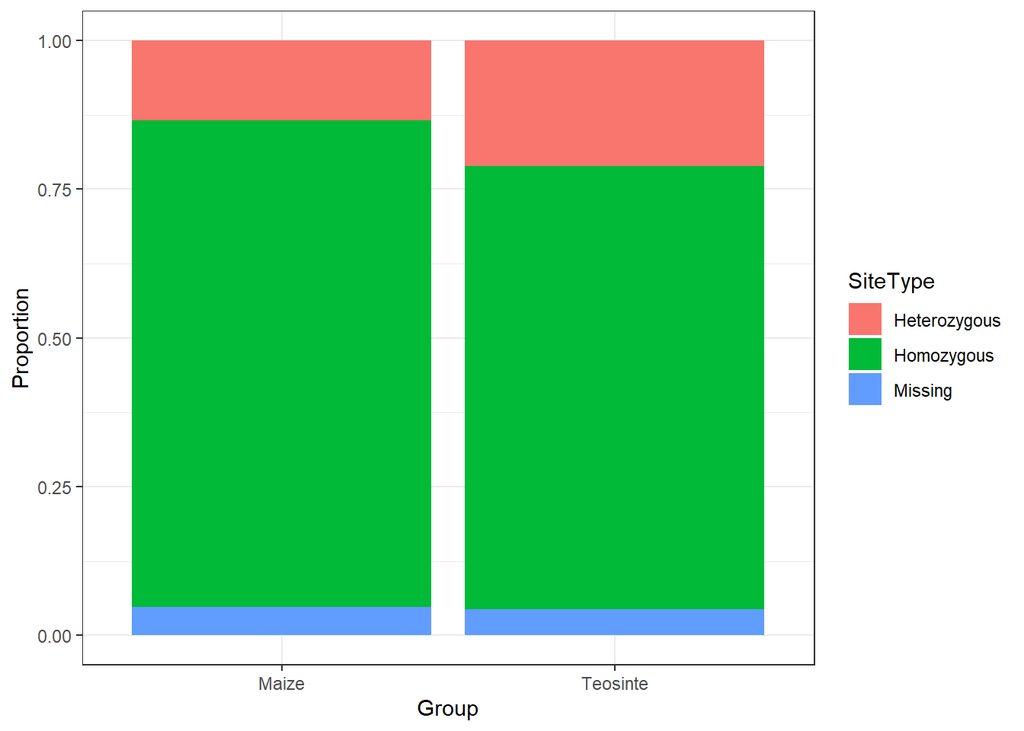

```r
ggplot(combined_long, aes(x = Group, fill = SiteType)) +
  geom_bar(position = "fill") +
  ylab("Proportion") +
  theme_bw()
```

##Your own visualization

The aim is to make a graph showing if individuals across groups are more/less genetically diverse. First, create a new data frame (by using the previously made combined_long data frame) with columns “Group,” “Sample,” and “Heterozygosity.” For each sample, Heterozygosity is calculated as the proportion of heterozygous sites, using mean(SiteType == “Heterozygous”), where TRUE corresponds to a site being heterozygous.”

```r
hetero_rate <- combined_long %>%
  filter(SiteType != "Missing") %>%
  group_by(Group, Sample) %>%
  summarise(
    heterozygosity = mean(SiteType == "Heterozygous")
  )
```

Then plot to show how often each sample within each group is heterozygous.

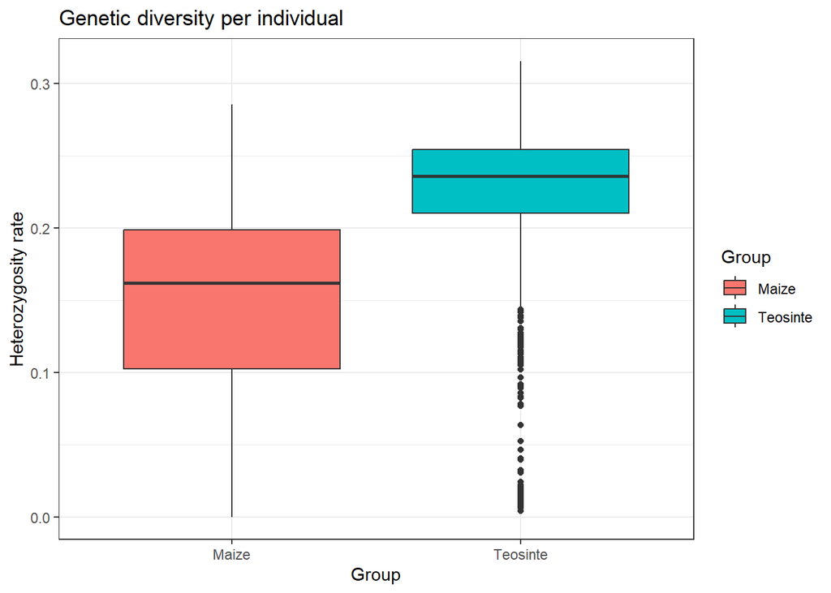

```r
ggplot(hetero_rate, aes(x = Group, y = heterozygosity, fill = Group)) +
  geom_boxplot() +
  ylab("Heterozygosity rate") +
  ggtitle("Genetic diversity per individual") +
  theme_bw()
```